# Intro to Time Series Analysis

## Ch. 5: Moving Average Model

Models with autocorrelation can be constructed from white noise. A weighted sum of current and previous noise is called a **simple moving average process**. Note that *simple* indicates that we are dealing with the simplest, first oder case. Formally, this can be described as:
$$Y_t = \mu + \epsilon_t + \theta \epsilon_{t-1}$$
$\epsilon_t$ is mean zero white noise. Respective parameters of the process are:

- Mean $\mu$
- Slope $\theta$
- White noise variance $\sigma^2_\epsilon$

If the slope $\theta = 0$ Y_t is White Noise $(\mu, \sigma^2_\epsilon)$. If $\theta \neq 0$ then $Y_t(\epsilon_t, \epsilon_{t-1})$ and the process is autocorrelated.

The MA process has autocorrelation as determined by the slope parameter $\theta$. However, it only has autocorrelation for lag 1 (one period). Note:

- Only lag 1 autocorrelation is non-zero for the MA model.

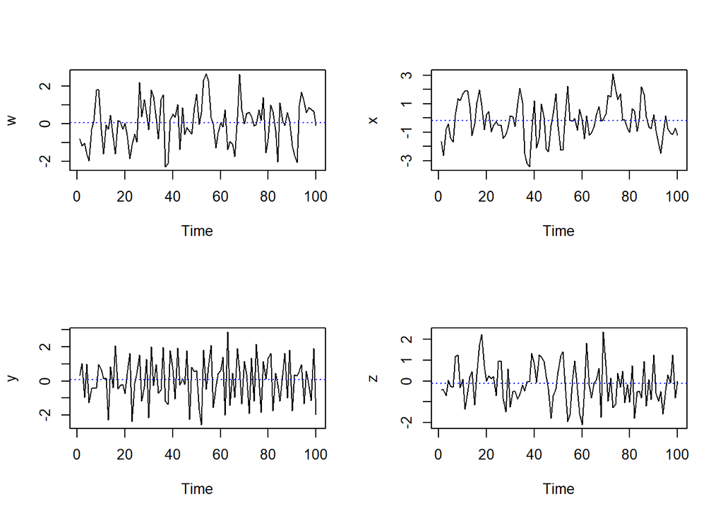

```r
# Simulate MA(1) model with differen slopes
w <- arima.sim(model = list(ma = 0.5), n=100)
x <- arima.sim(model = list(ma = 0.9), n=100)
y <- arima.sim(model = list(ma = -0.5), n=100)
z <- arima.sim(model = list(ma = 0), n=100)

par(mfrow=c(2,2))
ts.plot(w)
abline(h=mean(w), lty=3, col="blue")

ts.plot(x)
abline(h=mean(x), lty=3, col="blue")

ts.plot(y)
abline(h=mean(y), lty=3, col="blue")

ts.plot(z)
abline(h=mean(z), lty=3, col="blue")
```

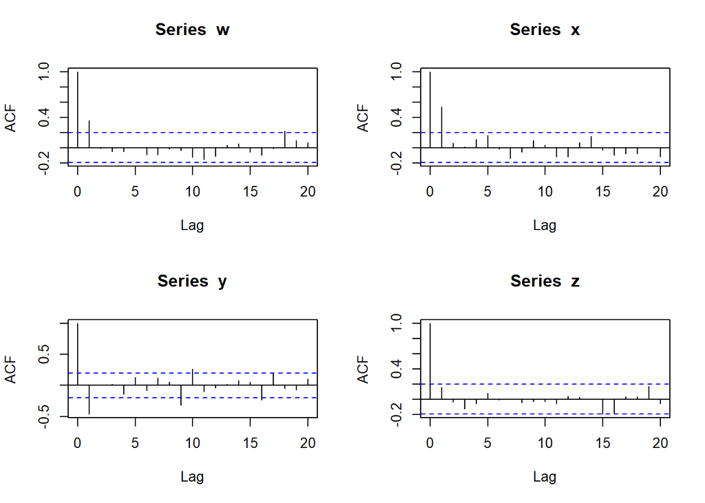

```r
# Calculate ACF
par(mfrow=c(2,2))
acf(w)
acf(x)
acf(y)
acf(z)
```

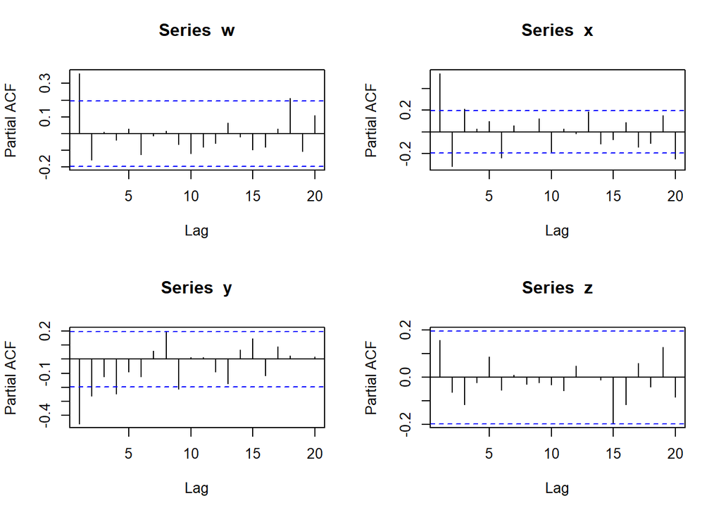

```r
# Calculate PACF
par(mfrow=c(2,2))
pacf(w)
pacf(x)
pacf(y)
pacf(z)
```

Next we will apply the MA model to changes in inflation rate of the mishigan data that we already used before.

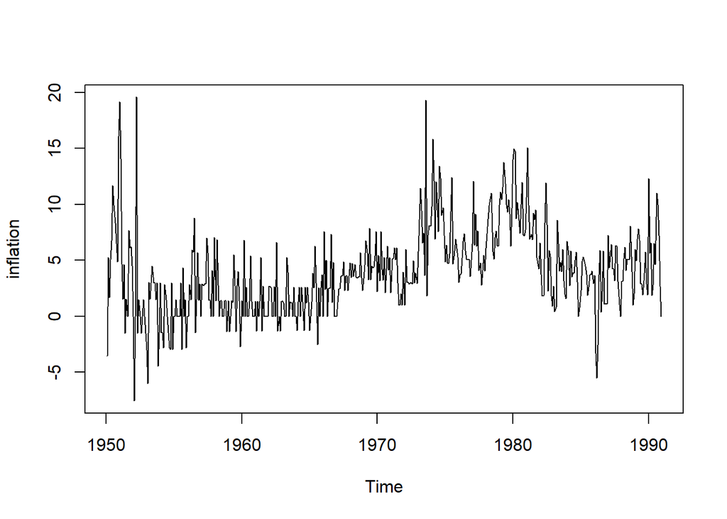

```r
data(Mishkin, package = "Ecdat")
inflation <- as.ts(Mishkin[,1])
inflation_diff <- diff(inflation)
ts.plot(inflation)
```

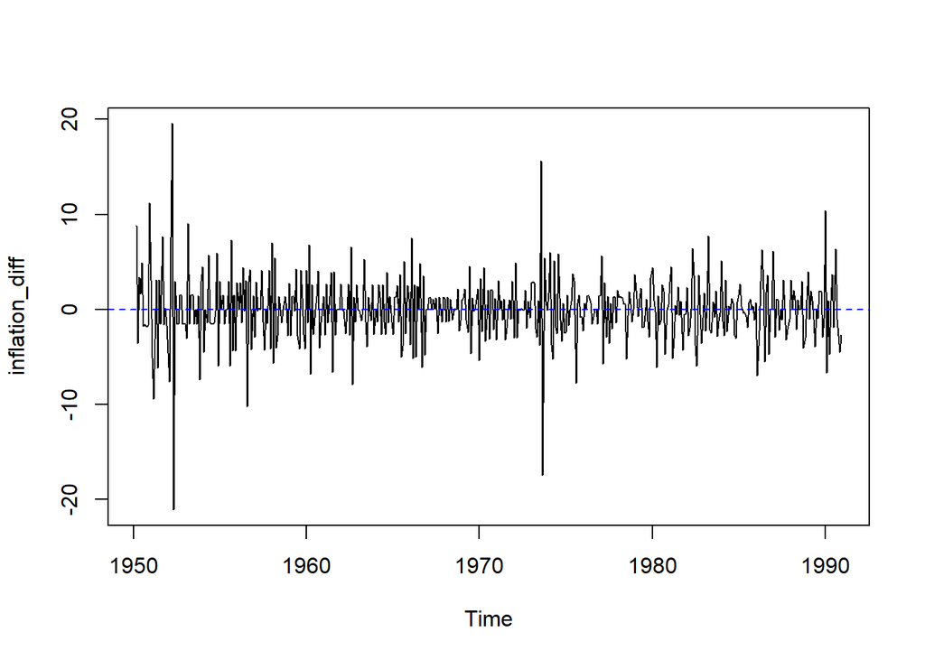

```r
ts.plot(inflation_diff)
abline(h = mean(inflation_diff), col="blue", lty=2)
```

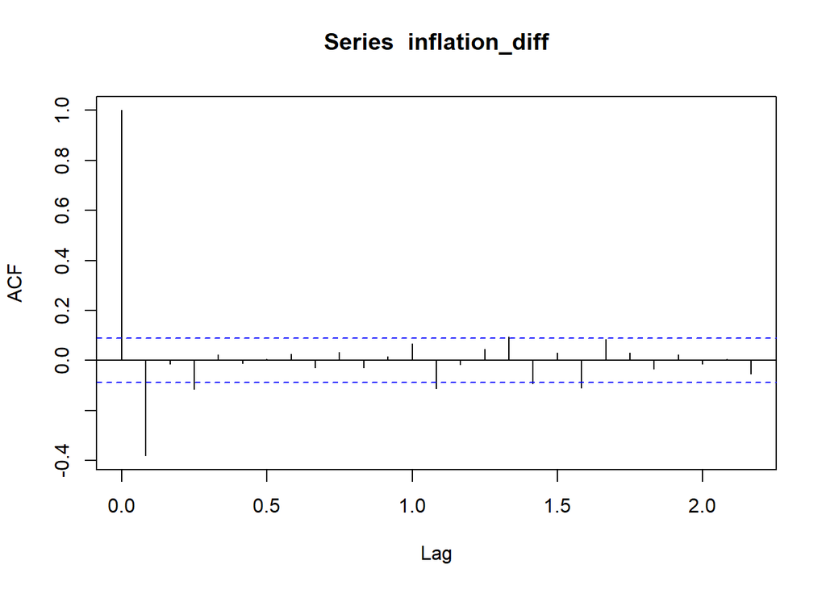

```r
acf(inflation_diff)
```

```r
# Estimate MA model using arima()
inflation_diff_ma <- arima(inflation_diff, order=c(0, 0, 1))
print(inflation_diff_ma)
```

```
##
## Call:
## arima(x = inflation_diff, order = c(0, 0, 1))
##
## Coefficients:
##           ma1  intercept
##       -0.7932     0.0010
## s.e.   0.0355     0.0281
##
## sigma^2 estimated as 8.882:  log likelihood = -1230.85,  aic = 2467.7
```

Again, we want to extract fitted values and compare them to our observerd values. The estimated model is:
$$\hat{Y_t} = \hat{\mu} + \hat{\theta} \hat{\epsilon}_{t-1}$$
Using the estimated residuals $\hat{\epsilon_t}$ we get the fitted values using the following equation
$$\hat{Y_t} = Y_t - \hat{\epsilon}_t$$

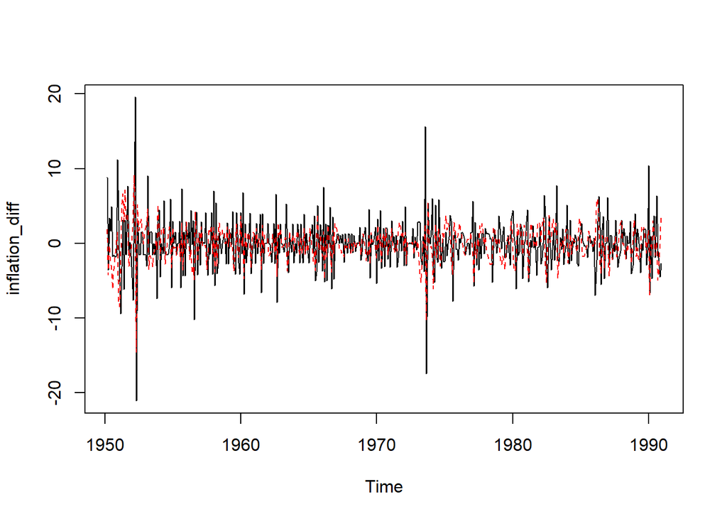

```r
# Get fitted values: Difference y_t and residuals
# using residuals() function or $residuals
inflation_diff_ma_fitted <- inflation_diff - inflation_diff_ma$residuals

# All data, fitted values
ts.plot(inflation_diff)
points(inflation_diff_ma_fitted, type="l", col="red", lty=2)
```

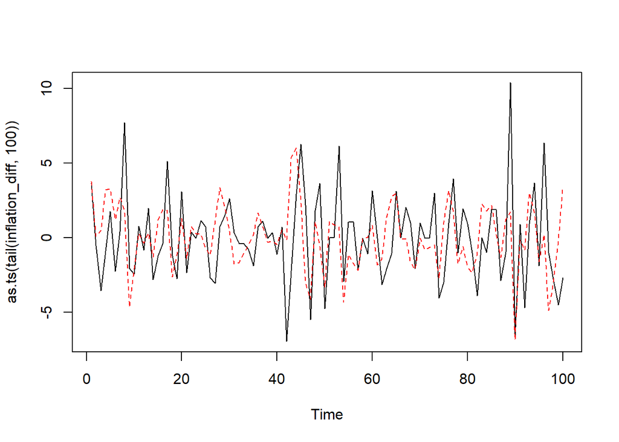

```r
# Last 100 observations, fitted values
ts.plot(as.ts(tail(inflation_diff,100)))
points(tail(inflation_diff_ma_fitted,100), type="l", col="red", lty=2)
```

There is a close relationship between fitted values and observed values indicating that even this simple MA model explains a lot of the variations in the data, which is nice. However, of course this can be fine-tuned even further with more sophisticated techniques. However, expect that even highly advanced models are only a moderate improvement. As in the AR model it can be noted that these rather simplistic models which take in only previous values and no external information are amazingly accurate. This means that a time series itself contains a lot of information on how this process continues.

Next: Predictions!

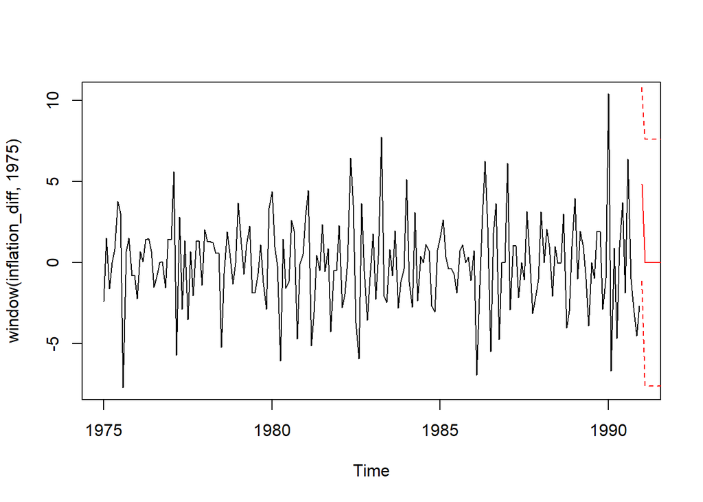

```r
# using predict() function
inflation_diff_ma_fc12 <-predict(inflation_diff_ma, 12)

fc12_se <- inflation_diff_ma_fc12$se

# plot the data, forecast and 95% intervals
ts.plot(window(inflation_diff, 1975))
points(inflation_diff_ma_fc12$pred, type="l", col="red", lty=1)
points(inflation_diff_ma_fc12$pred + 2*fc12_se, type="l", col="red", lty=2)
points(inflation_diff_ma_fc12$pred - 2*fc12_se, type="l", col="red", lty=2)
```

For January 1991 we predict an inflation change $\Delta Y_{1991:1}$ of 4.8316 with a standard deviation $\sigma_\epsilon =$ 2.9802. Note that following predictions are all close to 0. The model “lives” from exogenous shocks which it absorbs. The model has only memory (or autocorrelation) for one time length

In this model there are no shocks beyond January and, thus, it predicts almost no change in the absence of any external shocks.

## Compare MA and AR processes

Similar but different. Both have WN errors. In MA model we regress today’s value on yesterday’s noise. In the AR model we regress today’s value on yesterday’s observation.

However, the MA(1) model only has autocorrelation at one lag but the AR model has autocorrelation at many lags.

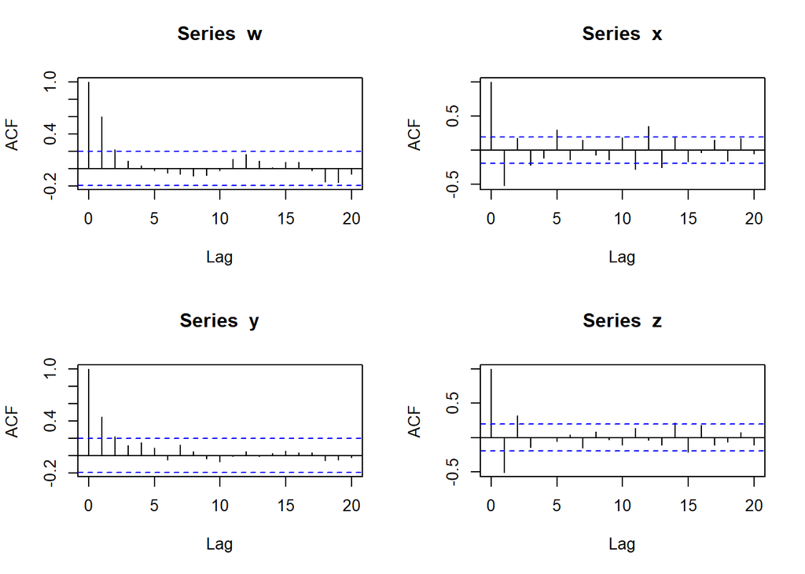

```r
#
w <- arima.sim(model = list(ma = 0.75), n= 100)
x <- arima.sim(model = list(ma = -0.75), n= 100)
y <- arima.sim(model = list(ar = 0.48), n = 100)
z <- arima.sim(model = list(ar = -0.48), n = 100)

par(mfrow=c(2,2))
acf(w)
acf(x)
acf(y)
acf(z)
```

Estimating these models results in autocorrelation coefficients of approximately $\pm 0.48$.

In the MA model this positive/negative shock runs out after just one period and autocorrelation is close to zero for all subsequent periods.

In the AR case the autocorrelation is more persistent. If there is positive autocorrelation the autocorrelation decreases steadily, whereas with negative autocorrelation coefficient there is an oscillatory pattern, changing between positive and negative in the acf.

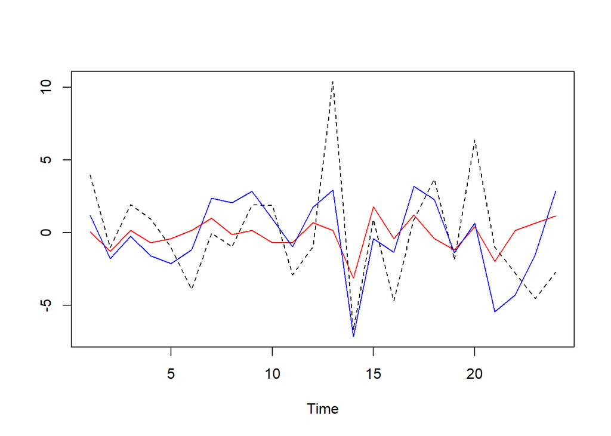

```r
# Fitting an AR and MA model for last 100 observations of inflation
inflation24_diff <- as.ts(tail(diff(inflation), 24))

inflation24_diff_ar <- arima(inflation24_diff, order=c(1,0,0))
inflation24_diff_ar_fitted <- inflation24_diff - inflation24_diff_ar$residuals

inflation24_diff_ma <- arima(inflation24_diff, order=c(0,0,1))
inflation24_diff_ma_fitted <- inflation24_diff - inflation24_diff_ma$residuals

ts.plot(cbind(inflation24_diff, inflation24_diff_ar_fitted, inflation24_diff_ma_fitted), lty=c(2,1,1), col=c(1,"red","blue"))
```

```r
# Estimate full model and compare using AIC, BIC
inflation_diff_ar <- arima(inflation_diff, order=c(1,0,0))
AIC(inflation_diff_ar)
```

```
## [1] 2542.679
```

```r
BIC(inflation_diff_ar)
```

```
## [1] 2555.262
```

```r
inflation_diff_ma <- arima(inflation_diff, order=c(0,0,1))
AIC(inflation_diff_ma)
```

```
## [1] 2467.703
```

```r
BIC(inflation_diff_ma)
```

```
## [1] 2480.286
```

Information criteria can be used to determine model performance. Most commonly used are the akaike information criterion (aic) and the bayesian-schwartz information criterion (bic). In both cases (aic and bic) the MA model performs better as it has a lower value for both criteria. We prefer the fit of the MA model here.